# Bicinrivas, estaciones de alquiler de Bicis en Rivas Vaciamadrid

Realizado por Irene Acosta Huesca

A continuación se encontrará la realización de la cuarta práctica de la asignatura de Periodismo de Datos. En esta, se reproducen los datos ofrecidos por el Ayuntamiento de Rivas Vaciamadrid, que se encuentran en el Portal de de Datos del Gobierno: [datos.gob.es](https://datos.gob.es/es/catalogo/l01281230-bicinrivas), en los que se detalla la localización de los puntos de estacionamiento de las bicicletas de alquiler del servicio municipal Bicinrivas. Además, en el segundo apartado de la práctica se inserta un mapa con una [ruta para bici por la laguna del Campillo](https://datos.gob.es/es/catalogo/l01281230-rutas-verdes) que comienza en el mismo punto que uno de los estacionamientos del servicio Bicinrivas.

```python
import pandas as pd
```

## Establecemos la variable

Tras haber configurado la librería pandas como `pd`, debemos crear la variable que se establece con el `=`y se escriben entre comillas porque se trata una cadena de caracteres, lo que se define como string. Del mismo modo, la variable se establece con la url donde encontramos los datos que vamos a necesitar. En este caso la definimos a través del acrónimo "bici", para saber que está relacionado con los estacionamientos de alquiler.

```python
url_bici = 'https://datosabiertos.rivasciudad.es/dataset/8f444e87-99a9-453c-b4f6-74d72ddc6908/resource/09b242f7-1b58-413e-a492-f689244bf036/download/bicinrivas.csv'
```

## DataFrame

Se define DataFrame a través de `df`, se trata de una herramienta por la cual podemos podemos organizar y almacenar una estructura de datos. Del mismo modo con anterioridad hemos importado la biblioteca ya instalada `pandas`a través de la convección `pd`. Dentro de Pandas hay una función que nos permite leer los datos que contiene un archivo, en este caso un csv, por ello para que el DataFrame lea los datos a través de pandas ponemos la función: `pd.read_csv`. Esta función lee archivos del DataFrame que son valores que se separan por comas, según explican de la própia página de pandas: ["Read a comma-separated values (csv) file into DataFrame"](https://pandas.pydata.org/docs/reference/api/pandas.read_csv.html).

```python
df_bici = pd.read_csv(url_bici)
```

El siguiente paso será escribir la función definida en el paso anterior,`df_bici`, con la que comprobamo que Python ha creado un DataFrame, es decir una tabla. Esta tabla, o su contenido son los datos del archivo csv que hemos establecido como variable

```python
df_bici
```

|  | LON | LAT | NOMBRE | DIRECCION | BARRIO |
| --- | --- | --- | --- | --- | --- |
| 0 | -3.520486 | 40.328383 | 1 Bicinrivas. Metro Rivas Vacimadrid | Cl. Wenceslao, s/n | Este |
| 1 | -3.525362 | 40.341797 | 2 Bicinrivas. Metro Rivas Futura | Av. José Hierro | Centro |
| 2 | -3.534379 | 40.349769 | 3 Bicinrivas.. Empresa Municipal de la Vivienda | Av. José Hierro, 36 | Centro |
| 3 | -3.547854 | 40.354863 | 4 Bicinrivas. Ayuntamiento | Pz. de la Constitución | Centro |
| 4 | -3.547996 | 40.367036 | 5 Bicinrivas. Metro Rivas Urbanizaciones | CL. Abogados de Atocha s/n | Oeste |
| 5 | -3.534000 | 40.360611 | 6 Bicinrivas. Centro Comercial Santa Mónica | Cl. Acacias, 120 | Centro |
| 6 | -3.517559 | 40.356472 | 7 Bicinrivas. Zona Cerro del TelÃ©grafo | Av. Pilar Miró | Centro |
| 7 | -3.512074 | 40.328677 | 8 Bicinrivas. Rivas Casco Antiguo | Av. Levante | Este |
| 8 | -3.531802 | 40.371546 | 9 Bicinrivas. Paseo de las Provincias | Av. de los Almendros, 198 | Oeste |
| 9 | -3.539709 | 40.377375 | 10 Bicinrivas. Barrio de la Luna | Cl. Margarita Xirgu con Madres de la Plaza de ... | Oeste |

Para conocer las caracterísitcas de la tabla y sus componentes de manera rápida y ágil utilizaremos las funciones: `df_bici.info()`, para ver el contenido general de la tabla, y `df_bici.columns` para ver solamente las columnas que componen dicha tabla.

```python
df_bici.info()
```

```
<class 'pandas.core.frame.DataFrame'>
RangeIndex: 10 entries, 0 to 9
Data columns (total 5 columns):
 #   Column     Non-Null Count  Dtype
---  ------     --------------  -----
 0   LON        10 non-null     float64
 1   LAT        10 non-null     float64
 2   NOMBRE     10 non-null     object
 3   DIRECCION  10 non-null     object
 4   BARRIO     10 non-null     object
dtypes: float64(2), object(3)
memory usage: 528.0+ bytes
```

> Cabe mencionar los tipos de datos, `dtype`, que vemos almacenados en el DataFrame de Python ya que afecta a las funciones que podemos hacer con él. En este caso encontramos numéricos de punto flotante (`float`), ya qeu tienen puntos decimalis y por eso Pandas asigna el dato `float` a toda la columna para que no se piertan los decimales. Pero también encontramos de datos de texto se conoce como secuencia de caracteres o string. Pandas reconocecomo objetos (`objetc`) y son el dtype más general y como ocurre en este DataFrame es asifnado ta que las columnas contienen tipos de datos mixtos, es decir tanto números como secuencias de caracteres. Por todo esto la información del tata frame nos dice que hay tipos de datos (`dtypes`): `float64(2)`, `object(3)`.

```python
df_bici.columns
```

```
Index(['LON', 'LAT', 'NOMBRE', 'DIRECCION', 'BARRIO'], dtype='object')
```

### Conocemos los valores del DataFrame con funciones

A continuación, extraeremos información de los valores que componen el DataFrame para conocer más a cerca de estos datos a través de la función `df_bici['']`. Por ejemplo, en el siguiente apartado se utiliza la función `df_bici['nombre de la columna']` para saber específicamente los vlores de las diferentes columnas. Por ejemplo utilizamos `df_bici['DIRECCION']`para saber específicamente la ubicación de las diferentes estaciones del servicio municipal Bicinrivas; haremos lo mismo con las columnas 'NOMBRE' y 'BARRIO'.

```python
df_bici['DIRECCION']
```

```
0                                   Cl. Wenceslao, s/n
1                                      Av. José Hierro
2                                  Av. José Hierro, 36
3                               Pz. de la Constitución
4                           CL. Abogados de Atocha s/n
5                                     Cl. Acacias, 120
6                                       Av. Pilar Miró
7                                          Av. Levante
8                            Av. de los Almendros, 198
9    Cl. Margarita Xirgu con Madres de la Plaza de ...
Name: DIRECCION, dtype: object
```

```python
df_bici['NOMBRE']
```

```
0               1 Bicinrivas. Metro Rivas Vacimadrid
1                   2 Bicinrivas. Metro Rivas Futura
2    3 Bicinrivas.. Empresa Municipal de la Vivienda
3                         4 Bicinrivas. Ayuntamiento
4           5 Bicinrivas. Metro Rivas Urbanizaciones
5        6 Bicinrivas. Centro Comercial Santa Mónica
6            7 Bicinrivas. Zona Cerro del TelÃ©grafo
7                  8 Bicinrivas. Rivas Casco Antiguo
8              9 Bicinrivas. Paseo de las Provincias
9                   10 Bicinrivas. Barrio de la Luna
Name: NOMBRE, dtype: object
```

```python
df_bici['BARRIO']
```

```
0      Este
1    Centro
2    Centro
3    Centro
4     Oeste
5    Centro
6    Centro
7      Este
8     Oeste
9     Oeste
Name: BARRIO, dtype: object
```

A través de la función `df_bici['BARRIO']` conocemos los valores que compone esta única columna. Aunque en el municipio de Rivas Vaciamadrid la lista no es muy larga, si quisieramos saber solo los barrios en los que se encuentran las paradas Bicinrivas usamos la función `pd.unique(df_bici['BARRIO'])`. Veremos que nos devuelve los valores únicos de la columna del DataFrame, no ordenados, pero si en orden de aparción.

```python
pd.unique(df_bici['BARRIO'])
```

```
array(['Este', 'Centro', 'Oeste'], dtype=object)
```

Del mismo modo, si quisieramos añadir más información a estos valores únicos, como saber la frecuencia, el barrio dónde más estacionamientos de alquiler hay etc. utilizaremos la siguiente función:

```python
df_bici['BARRIO'].describe()
```

```
count         10
unique         3
top       Centro
freq           5
Name: BARRIO, dtype: object
```

## Creamos tablas

Hasta el momento hemos definido las columnas con los valores de las mismas que nos interesa, en este caso 'NOMBRE', de la estación, 'BARRIO' y 'DIRECCION', en donde que se encuentra dicha estación. A través de la función `df.set_index('')`, que nos permite establecer un índice dentro del DataFrame utilizando las columnas existentes, según se explica en la propia página de [pandas](https://pandas.pydata.org/docs/reference/api/pandas.DataFrame.set_index.html).

```python
df_bici.set_index('BARRIO')
```

| BARRIO | LON | LAT | NOMBRE | DIRECCION |
| --- | --- | --- | --- | --- |
| Este | -3.520486 | 40.328383 | 1 Bicinrivas. Metro Rivas Vacimadrid | Cl. Wenceslao, s/n |
| Centro | -3.525362 | 40.341797 | 2 Bicinrivas. Metro Rivas Futura | Av. José Hierro |
| Centro | -3.534379 | 40.349769 | 3 Bicinrivas.. Empresa Municipal de la Vivienda | Av. José Hierro, 36 |
| Centro | -3.547854 | 40.354863 | 4 Bicinrivas. Ayuntamiento | Pz. de la Constitución |
| Oeste | -3.547996 | 40.367036 | 5 Bicinrivas. Metro Rivas Urbanizaciones | CL. Abogados de Atocha s/n |
| Centro | -3.534000 | 40.360611 | 6 Bicinrivas. Centro Comercial Santa Mónica | Cl. Acacias, 120 |
| Centro | -3.517559 | 40.356472 | 7 Bicinrivas. Zona Cerro del TelÃ©grafo | Av. Pilar Miró |
| Este | -3.512074 | 40.328677 | 8 Bicinrivas. Rivas Casco Antiguo | Av. Levante |
| Oeste | -3.531802 | 40.371546 | 9 Bicinrivas. Paseo de las Provincias | Av. de los Almendros, 198 |
| Oeste | -3.539709 | 40.377375 | 10 Bicinrivas. Barrio de la Luna | Cl. Margarita Xirgu con Madres de la Plaza de ... |

Tras seleccionar como índice la columna 'BARRIO' sigue siendo complicado leer la tabla, por ello crearemos un MultiIndex usando dos culumnas, en este caso'BARRIO' y 'NOMBRE' con la misma función, solamente que ahora las columnas van también entre corchetes.

```python
df_bici.set_index(['BARRIO','NOMBRE'])
```

| BARRIO | NOMBRE | LON | LAT | DIRECCION |
| --- | --- | --- | --- | --- |
| Este | 1 Bicinrivas. Metro Rivas Vacimadrid | -3.520486 | 40.328383 | Cl. Wenceslao, s/n |
| Centro | 2 Bicinrivas. Metro Rivas Futura | -3.525362 | 40.341797 | Av. José Hierro |
|  | 3 Bicinrivas.. Empresa Municipal de la Vivienda | -3.534379 | 40.349769 | Av. José Hierro, 36 |
|  | 4 Bicinrivas. Ayuntamiento | -3.547854 | 40.354863 | Pz. de la Constitución |
| Oeste | 5 Bicinrivas. Metro Rivas Urbanizaciones | -3.547996 | 40.367036 | CL. Abogados de Atocha s/n |
| Centro | 6 Bicinrivas. Centro Comercial Santa Mónica | -3.534000 | 40.360611 | Cl. Acacias, 120 |
|  | 7 Bicinrivas. Zona Cerro del TelÃ©grafo | -3.517559 | 40.356472 | Av. Pilar Miró |
| Este | 8 Bicinrivas. Rivas Casco Antiguo | -3.512074 | 40.328677 | Av. Levante |
| Oeste | 9 Bicinrivas. Paseo de las Provincias | -3.531802 | 40.371546 | Av. de los Almendros, 198 |
|  | 10 Bicinrivas. Barrio de la Luna | -3.539709 | 40.377375 | Cl. Margarita Xirgu con Madres de la Plaza de ... |

En el siguiente paso utilizaremos una nueva función: `pivot_table`. Esta función es también de utilidad para resumir datos ["al estilo de una hoja de cálculo como DataFrame"](https://pandas.pydata.org/docs/reference/api/pandas.DataFrame.pivot_table.html?highlight=pivot_table). En la anterior tabla encontrábamos más resumido y se entendían mejor los valores, las coordenadas de longitud y latitud no nos interesan, por ello estableceremos las diferentes estaciones de alquiler de bici agrupadas por el bario en el que se encuentran:

```python
df_bici.pivot_table('LON', ['BARRIO','NOMBRE', 'DIRECCION'])
```

| BARRIO | NOMBRE | DIRECCION | LON |
| --- | --- | --- | --- |
| Centro | 2 Bicinrivas. Metro Rivas Futura | Av. José Hierro | -3.525362 |
|  | 3 Bicinrivas.. Empresa Municipal de la Vivienda | Av. José Hierro, 36 | -3.534379 |
|  | 4 Bicinrivas. Ayuntamiento | Pz. de la Constitución | -3.547854 |
|  | 6 Bicinrivas. Centro Comercial Santa Mónica | Cl. Acacias, 120 | -3.534000 |
|  | 7 Bicinrivas. Zona Cerro del TelÃ©grafo | Av. Pilar Miró | -3.517559 |
| Este | 1 Bicinrivas. Metro Rivas Vacimadrid | Cl. Wenceslao, s/n | -3.520486 |
|  | 8 Bicinrivas. Rivas Casco Antiguo | Av. Levante | -3.512074 |
| Oeste | 10 Bicinrivas. Barrio de la Luna | Cl. Margarita Xirgu con Madres de la Plaza de Mayo | -3.539709 |
|  | 5 Bicinrivas. Metro Rivas Urbanizaciones | CL. Abogados de Atocha s/n | -3.547996 |
|  | 9 Bicinrivas. Paseo de las Provincias | Av. de los Almendros, 198 | -3.531802 |

## Creamos un mapa

Muchas veces, más aún si no conocemos el lugar, a través de un mapa visualizamos mejor los lugares. En este caso, los datos usados son localizaciones de los estacionamientos de alquiler de bicis municipales del Ayuntamiento de Rivas Vaciamadrid. Los `dtype` que nos interesan son `objects`, es decir caracteres, nombres de sitios. Por ello, a través de la librería folium se representará geoespacialmente las estaciones Bicinrivas. Esto en el caso de querer elegir una, nos daría una mayor facilidad al ver por dónde se ubican exactamente.

```python
import folium
```

Ya hemos importado la libreria folium, ahora debemos definir la geolocalización del municipio de Rivas Vaciamadrid a través de sus coordenadas. Para ello definiremos la localización a través del acrónimo "geo_rivas".

```python
geo_rivas = [40.3297, -3.51694]
```

Ya definida la variable de localización creamos el mapa a través de folium, una librería de Python con la que visualizamos el mapa, hace uso simplemente la latitud y la longitud del punto espacial. Definimos el mapa como "mapa_rivas" e importamos folium y se representa el mapa. Si quisieramos mostrarlo en el cuaderno simplemente lo solicitamos con la definición, lo que haremos al final cuando esté completo el mapa.

```python
mapa_rivas = folium.Map(location=geo_rivas)
```

```python
mapa_rivas = folium.Map(location=[40.3297, -3.51694])
```

```python
folium.Map(location=[40.3297, -3.51694], zoomstar=50, titles="Stamen Terrain")
```

Make this Notebook Trusted to load map: File -> Trust Notebook

[interactive chart not shown]

### Insertamos marcadores en el mapa

La realización del mapa de Rivas Vaciamadrid tiene como objetivo que se puedan **indentificar las estaciones de alquiler Bicinrivas** que hay en el municipio. Por ello, utilizaremos la función de `folium.Marker()` para agregar un marcador a cada localización y que este se vea representado en el mapa_rivas ya creado.

Lo primero que hacemos es definir el `tooltip`. Después, através de la función `folium.CircleMarker()` pintamos en el mapa un círculo azul que engloba el municipio de Rivas, dónde dentro encontramos los diferentes **estacionamientos de alquiler de bici** definidos con la función ya mencionada, `folium.Marker()`, asociándolos a través de sus coordenadas geográficas.

```python
tooltip1 = "Pincha para ver la parada BicinRivas"
```

```python
folium.CircleMarker(location=[40.3297, -3.51694], radius=70, popup="Rivas Vaciamadrid",color="#3186cc", fill=True, fill_color="#3186cc",).add_to(mapa_rivas)
folium.Marker([40.328383, -3.520486], popup="Bicinrivas Metro Rivas Vacimadrid. Ubicación: Calle Wenceslao", tooltip=tooltip1, icon = folium.Icon(color="pink")).add_to(mapa_rivas)
folium.Marker([40.3289459, -3.5209703], popup="Bicinrivas Rivas Casco Antiguo. Ubicación: Av. de Levante", tooltip=tooltip1, icon = folium.Icon(color="pink")).add_to(mapa_rivas)
folium.Marker([40.341797, -3.525362], popup="Bicinrivas Metro Rivas Futura. Ubicación: Avenida José Hierro", tooltip=tooltip1, icon = folium.Icon(color="red")).add_to(mapa_rivas)
folium.Marker([40.349769, -3.534379], popup="Bicinrivas Empresa Municipal de la Vivienda. Ubicación: Avenida José Hierro, 36", tooltip=tooltip1, icon = folium.Icon(color="red")).add_to(mapa_rivas)
folium.Marker([40.354863, -3.547854], popup="Bicinrivas Ayuntamiento. Ubicación: Plaza de la Constitución", tooltip=tooltip1, icon = folium.Icon(color="red")).add_to(mapa_rivas)
folium.Marker([40.360611, -3.534000], popup="Bicinrivas Centro Comercial Santa Mónica. Ubicación: Calle Acacias, 120", tooltip=tooltip1, icon = folium.Icon(color="red")).add_to(mapa_rivas)
folium.Marker([40.356472, -3.517559], popup="Bicinrivas Zona Cerro del Telégrafo. Ubicación: Avenida Pilar Miró", tooltip=tooltip1, icon = folium.Icon(color="red")).add_to(mapa_rivas)
folium.Marker([40.367036, -3.547996], popup="Bicinrivas Metro Rivas Urbanizaciones. Ubicación: Calle Abogados de Atocha", tooltip=tooltip1, icon = folium.Icon(color="green")).add_to(mapa_rivas)
folium.Marker([40.371546, -3.531802], popup="Ubicación: Avenida de los Almendros, 198", tooltip=tooltip1, icon = folium.Icon(color="green")).add_to(mapa_rivas)
folium.Marker([40.377375, -3.539709], popup=" Bicinrivas. Paseo de las Provincias. Bicinrivas Barrio de la Luna. Ubicación: Calle Margarita Xirgu con Madres de la Plaza de Mayo", tooltip=tooltip, icon = folium.Icon(color="green")).add_to(mapa_rivas)
```

```
<folium.map.Marker at 0x7f6f0af72310>
```

```python
mapa_rivas
```

Make this Notebook Trusted to load map: File -> Trust Notebook

[interactive chart not shown]

# Ruta en bici por las lagunas del Campillo

En esta segunda parte de la práctica cuatro, se ha escogido una de las rutas verdes que hay en el municipio que se puede realizar en bici. La estación de servicio de alquiler de bicis "Metro Rivas Vacimadrid", que se encuentra en la calle Wenceslao, es la primera parda de la ruta por la laguna del Campillo. Por ello se ha escogido esta ruta para poder alquilar una bici y disfrutar del paisaje de los cortados de la laguna ubicad en el Parque regional del Sureste.

En este apartado se realizarán los mismos pasos que en el ejercicio anterior. Se ha decidido crear un segundo apartado para practicar de nuevo y, del mismo modo, si se tratase de una publicación se debe añadir información complementaria a lo anterior y dar una utilidad así a la representación de los estacionaminetos de alquiler de bicis.

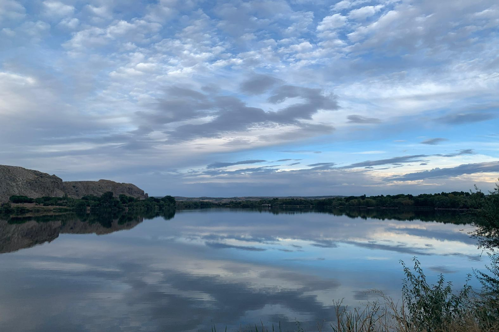

> *Imagen propia de la laguna del Campillo en la ruta verde de bici*

## Establecemos la variable

Ya configurada la librería pandas como `pd`, creamos la variable que se establece con el `=`y se escriben entre comillas porque se trata una cadena de caracteres, lo que se define como string.

```python
url_campillo = 'https://datosabiertos.rivasciudad.es/dataset/78f9ffb3-1950-4feb-a154-be24e365541d/resource/8acb9b6b-a74a-499f-8985-802427aa7d09/download/campillo.csv'
```

## Creamos el DataFrame

De nuevo empleamos la función que nos permite leer los datos que contiene un archivo, en este caso un csv, por ello para que el DataFrame lea los datos a través de pandas ponemos la función: `pd.read_csv`. Esta función lee archivos del DataFrame que son valores que se separan por comas, según explican de la própia página de pandas: ["Read a comma-separated values (csv) file into DataFrame"](https://pandas.pydata.org/docs/reference/api/pandas.read_csv.html).

```python
df_campillo = pd.read_csv(url_campillo)
```

```python
df_campillo
```

|  | LON | LAT | PARADA | DETALLE | IMAGEN | MAPA |
| --- | --- | --- | --- | --- | --- | --- |
| 0 | -3.495163 | 40.320240 | Parada 7 | En la bifurcación, coger el camino de la derec... | http://www.rivasciudad.es/portal/RecursosWeb/I... | http://sit.rivasciudad.es/web/publico/layar/po... |
| 1 | -3.492825 | 40.322634 | Parada 8 | A la derecha, se observa la finca privada El P... | http://www.rivasciudad.es/portal/RecursosWeb/I... | http://sit.rivasciudad.es/web/publico/layar/po... |
| 2 | -3.495165 | 40.323345 | Parada 9 | Rodeando la laguna, se ven los cantiles de Riv... | http://www.rivasciudad.es/portal/RecursosWeb/I... | http://sit.rivasciudad.es/web/publico/layar/po... |
| 3 | -3.504875 | 40.322207 | Parada 11 | Llegamos a una zona de recreo. | http://www.rivasciudad.es/portal/RecursosWeb/I... | http://sit.rivasciudad.es/web/publico/layar/po... |
| 4 | -3.511698 | 40.321165 | Parada 2 | Entrada a la Laguna El Campillo. A la izquierd... | http://www.rivasciudad.es/portal/RecursosWeb/I... | http://sit.rivasciudad.es/web/publico/layar/po... |
| 5 | -3.496833 | 40.323050 | Parada 10 | Se puede ver el eslalom de cipreses. A la dere... | http://www.rivasciudad.es/portal/RecursosWeb/I... | http://sit.rivasciudad.es/web/publico/layar/po... |
| 6 | -3.520219 | 40.328213 | Parada 1 | Estación de metro Rivas-Vaciamadrid. | http://www.rivasciudad.es/portal/RecursosWeb/I... | http://sit.rivasciudad.es/web/publico/layar/po... |
| 7 | -3.508474 | 40.318904 | Parada 3 | Seguimos por el camino, a la izquierda vemos l... | http://www.rivasciudad.es/portal/RecursosWeb/I... | http://sit.rivasciudad.es/web/publico/layar/po... |
| 8 | -3.504900 | 40.318118 | Parada 4 | Llegamos a una fuente de agua. A ambos lados p... | http://www.rivasciudad.es/portal/RecursosWeb/I... | http://sit.rivasciudad.es/web/publico/layar/po... |
| 9 | -3.500817 | 40.319273 | Parada 5 | Podemos ver la estación de aforo. Mediciones d... | http://www.rivasciudad.es/portal/RecursosWeb/I... | http://sit.rivasciudad.es/web/publico/layar/po... |
| 10 | -3.497793 | 40.320721 | Parada 6 | Seguimos por el camino que lleva al Centro de ... | http://www.rivasciudad.es/portal/RecursosWeb/I... | http://sit.rivasciudad.es/web/publico/layar/po... |
| 11 | -3.525332 | 40.319999 | Parada 4 | A lo largo de todo el camino y bordeando el rí... | http://www.rivasciudad.es/portal/RecursosWeb/I... | http://sit.rivasciudad.es/web/publico/layar/po... |

```python
df_campillo.info()
```

```
<class 'pandas.core.frame.DataFrame'>
RangeIndex: 12 entries, 0 to 11
Data columns (total 6 columns):
 #   Column   Non-Null Count  Dtype
---  ------   --------------  -----
 0   LON      12 non-null     float64
 1   LAT      12 non-null     float64
 2   PARADA   12 non-null     object
 3   DETALLE  12 non-null     object
 4   IMAGEN   12 non-null     object
 5   MAPA     12 non-null     object
dtypes: float64(2), object(4)
memory usage: 704.0+ bytes
```

```python
df_campillo[['PARADA','DETALLE']]
```

|  | PARADA | DETALLE |
| --- | --- | --- |
| 0 | Parada 7 | En la bifurcación, coger el camino de la derec... |
| 1 | Parada 8 | A la derecha, se observa la finca privada El P... |
| 2 | Parada 9 | Rodeando la laguna, se ven los cantiles de Riv... |
| 3 | Parada 11 | Llegamos a una zona de recreo. |
| 4 | Parada 2 | Entrada a la Laguna El Campillo. A la izquierd... |
| 5 | Parada 10 | Se puede ver el eslalom de cipreses. A la dere... |
| 6 | Parada 1 | Estación de metro Rivas-Vaciamadrid. |
| 7 | Parada 3 | Seguimos por el camino, a la izquierda vemos l... |
| 8 | Parada 4 | Llegamos a una fuente de agua. A ambos lados p... |
| 9 | Parada 5 | Podemos ver la estación de aforo. Mediciones d... |
| 10 | Parada 6 | Seguimos por el camino que lleva al Centro de ... |
| 11 | Parada 4 | A lo largo de todo el camino y bordeando el rí... |

## Creamos un mapa

De nuevo estos datos que nos da el DataFrame se leerán y entenderán mejor a través de su representación en un mapa. En este caso se ha dispuesto en el mapa cada parada de la ruta y la explicación de la misma que dan desde el Ayuntamiento de Rivas.

```python
import folium
```

Ya hemos importado la libreria folium, ahora debemos definir la geolocalización del municipio de Rivas Vaciamadrid a través de sus coordenadas. Para ello definiremos la localización a través del acrónimo "geo_lagunas". De neuvo, ya definida la variable de localización creamos el mapa a través de folium, una librería de Python con la que visualizamos el mapa, hace uso simplemente la latitud y la longitud del punto espacial. Definimos el mapa como "mapa_lagunas" e importamos folium y se representa el mapa. Si quisieramos mostrarlo en el cuaderno simplemente lo solicitamos con la definición, lo que haremos al final cuando esté completo el mapa.

```python
geo_lagunas = [40.32025, -3.5039916666667]
```

```python
mapa_lagunas = folium.Map(location=geo_lagunas)
```

```python
folium.Map(location=[40.32025, -3.5039916666667], zoomstar=12, titles="Statem Terrain")
```

Make this Notebook Trusted to load map: File -> Trust Notebook

[interactive chart not shown]

### Insertamos marcadores en el mapa

Recordamos que debemos definir el `tooltip`. Después, en esta práctica añadimos la función `folium.Circle` para señalar con un círculo rojo donde empieza la ruta y dónde se encuentra el servicio de alquiler de bicis de Bicinrivas. Al igual que en el anterior mapa, a través de la función `folium.CircleMarker()` pintamos un círculo azul que engloba la laguna del Campillo, el diámetro en el que se realizará la ruta. Lo práctico de los datos que nos ofrece el DataFrame es una guía por definidos con la función ya mencionada, `folium.Marker()`, asociándolos a través de sus coordenadas geográficas.

```python
tooltip = "Parada de la ruta por la laguna del Campillo"
```

```python
folium.Circle(radius=300, location=[40.328383, -3.520486], popup="Estación Bicinrivas en el Metro de Rivas", color="red", fill=False,).add_to(mapa_lagunas)
folium.CircleMarker(location=[40.32025, -3.5039916666667], radius=50, popup="Laguna del Campillo",color="#3186cc", fill=True, fill_color="#3186cc",).add_to(mapa_lagunas)
folium.Marker([40.328213, -3.520219], popup="PARADA 1: Estación de metro Rivas-Vaciamadrid", tooltip=tooltip, icon = folium.Icon(color="green")).add_to(mapa_lagunas)
folium.Marker([40.321165, -3.511698], popup="PARADA 2: Entrada a la Laguna El Campillo. A la izquierda podemos ver el Vivero de Ensayos El Campillo", tooltip=tooltip, icon = folium.Icon(color="blue")).add_to(mapa_lagunas)
folium.Marker([40.318904, -3.508474], popup="PARADA 3: Seguimos por el camino, a la izquierda vemos los cantiles de Rivas, y a la derecha el Rio Jarama", tooltip=tooltip, icon = folium.Icon(color="darkpurple")).add_to(mapa_lagunas)
folium.Marker([40.318118, -3.504900], popup="PARADA 4: Llegamos a una fuente de agua. A ambos lados podemos ver chopos, tarays, olmos y sauces. A lo largo de todo el camino y bordeando el río, se puede observar el bosque de ribera.", tooltip=tooltip, icon = folium.Icon(color="pink")).add_to(mapa_lagunas)
folium.Marker([40.319273, -3.500817], popup="PARADA 5: Podemos ver la estación de aforo. Mediciones del caudal del río, velocidad y calidad del agua", tooltip=tooltip, icon = folium.Icon(color="lightred")).add_to(mapa_lagunas)
folium.Marker([40.320721, -3.497793], popup="PARADA 6: Seguimos por el camino que lleva al Centro de Educación Ambiental “El Campillo”", tooltip=tooltip, icon = folium.Icon(color="orange")).add_to(mapa_lagunas)
folium.Marker([40.320240, -3.495163], popup="PARADA 7: En la bifurcación, coger el camino de la derecha, donde se ve el bosque de ribera del río. Más adelante, se ven los carrizales", tooltip=tooltip, icon = folium.Icon(color="purple")).add_to(mapa_lagunas)
folium.Marker([40.322634, -3.492825], popup="PARADA 8: A la derecha, se observa la finca privada El Piúl. Enfrente, podemos ver la laguna", tooltip=tooltip, icon = folium.Icon(color="gray")).add_to(mapa_lagunas)
folium.Marker([40.323345, -3.495165], popup="PARADA 9: Rodeando la laguna, se ven los cantiles de Rivas. Caseta para la observación de aves", tooltip=tooltip, icon = folium.Icon(color="lightblue")).add_to(mapa_lagunas)
folium.Marker([40.323050, -3.496833], popup="PARADA 10: Se puede ver el eslalom de cipreses. A la derecha podemos observar una fábrica de vigas", tooltip=tooltip, icon = folium.Icon(color="lightgray",icon="info-sign")).add_to(mapa_lagunas)
folium.Marker([40.322207, - 3.504875], popup="PARADA 11: Llegamos a una zona de recreo", tooltip=tooltip, icon = folium.Icon(color="darkred")).add_to(mapa_lagunas)
```

```
<folium.map.Marker at 0x7f6f0ae56730>
```

```python
mapa_lagunas
```

Make this Notebook Trusted to load map: File -> Trust Notebook

[interactive chart not shown]

Ponemos mapa_lagunas para ver el mapa terminado con los puntos de paradas de la ruta ya establecidas. En este caso cada parada tiene un color diferente, se buscaron los diferentes colores que se peuden utilizar y así diferenciar las 11 paradas que tienen la ruta. El índice es el siguiente:

- Color verde clarito, señalada con un círculo rojo = PARADA 1. Estación de metro Rivas-Vaciamadrid junto con la parada de alquiler de Bicinrivas.
- Color azul = PARADA 2: Entrada a la Laguna El Campillo. A la izquierda podemos ver el Vivero de Ensayos El Campillo.
- Color morado oscuro = PARADA 3: Seguimos por el camino, a la izquierda vemos los cantiles de Rivas, y a la derecha el Rio Jarama.
- Color rosa = PARADA 4: Llegamos a una fuente de agua.
- Color salmón = PARADA 5: Podemos ver la estación de aforo.
- Color naranja = PARADA 6: Seguimos por el camino que lleva al Centro de Educación Ambiental “El Campillo”
- Color morado clarito = PARADA 7: En la bifurcación, coger el camino de la derecha, donde se ve el bosque de ribera del río.
- Color gris oscuro = PARADA 8: A la derecha, se observa la finca privada El Piúl.
- Color azul clarito = PARADA 9: Rodeando la laguna, se ven los cantiles de Rivas.
- Color gris clarito = PARADA 10: Se puede ver el eslalom de cipreses.
- Color granate = PARADA 11: Llegamos a una zona de recreo.

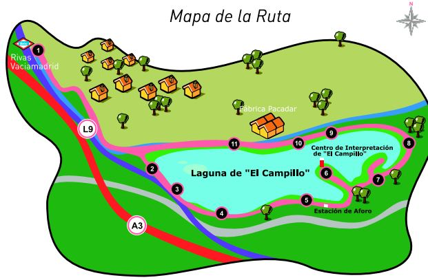